# ab_test_script

#SECTION 1. EXPLORATORY ANALYSIS ##1. Loading data and libraries

```r
library(tidyverse)
library(ggplot2)
library(readr)
library(shiny)
library(scales)
```

```r
df <- read_csv("data/ab_data.csv")
head(df) #first 6 lines
```

```
## # A tibble: 6 × 5
##   user_id timestamp           group     landing_page converted
##     <dbl> <dttm>              <chr>     <chr>            <dbl>
## 1  851104 2017-01-21 22:11:48 control   old_page             0
## 2  804228 2017-01-12 08:01:45 control   old_page             0
## 3  661590 2017-01-11 16:55:06 treatment new_page             0
## 4  853541 2017-01-08 18:28:03 treatment new_page             0
## 5  864975 2017-01-21 01:52:26 control   old_page             1
## 6  936923 2017-01-10 15:20:49 control   old_page             0
```

```r
glimpse(df)  #see the dataframe structure
```

```
## Rows: 294,478
## Columns: 5
## $ user_id      <dbl> 851104, 804228, 661590, 853541, 864975, 936923, 679687, 7…
## $ timestamp    <dttm> 2017-01-21 22:11:48, 2017-01-12 08:01:45, 2017-01-11 16:…
## $ group        <chr> "control", "control", "treatment", "treatment", "control"…
## $ landing_page <chr> "old_page", "old_page", "new_page", "new_page", "old_page…
## $ converted    <dbl> 0, 0, 0, 0, 1, 0, 1, 0, 1, 1, 0, 0, 0, 0, 0, 1, 0, 1, 0, …
```

```r
df <- df %>% #assign proper variable types
  mutate(
    group = as.factor(group),
    landing_page = as.factor(landing_page),
    converted = as.integer(converted),
    timestamp = ymd_hms(timestamp))

str(df) #all changes applied
```

```
## tibble [294,478 × 5] (S3: tbl_df/tbl/data.frame)
##  $ user_id     : num [1:294478] 851104 804228 661590 853541 864975 ...
##  $ timestamp   : POSIXct[1:294478], format: "2017-01-21 22:11:48" "2017-01-12 08:01:45" ...
##  $ group       : Factor w/ 2 levels "control","treatment": 1 1 2 2 1 1 2 1 2 2 ...
##  $ landing_page: Factor w/ 2 levels "new_page","old_page": 2 2 1 1 2 2 1 2 1 1 ...
##  $ converted   : int [1:294478] 0 0 0 0 1 0 1 0 1 1 ...
```

##2. Any NAs? / Пропуски в данных

```r
colSums(is.na(df))
```

```
##      user_id    timestamp        group landing_page    converted
##            0            0            0            0            0
```

```r
df %>%
  summarise(across(everything(), ~sum(is.na(.)) / n() * 100)) %>%
  pivot_longer(everything(), names_to = "Column", values_to = "Percent_Missing") %>%
  arrange(desc(Percent_Missing))
```

```
## # A tibble: 5 × 2
##   Column       Percent_Missing
##   <chr>                  <dbl>
## 1 user_id                    0
## 2 timestamp                  0
## 3 group                      0
## 4 landing_page               0
## 5 converted                  0
```

```r
#ideal dataframe, no cleaning needed
```

##3. Check data consistency for A/B tests For A/B tests, control and treatment groups should strictly correspond to old (A) and new (B) features. We need to clean the rows where observations are confused to ensure the relevance of experiment

```r
table(df$group, df$landing_page) #there are confused observations, let's filter them
```

```
##
##             new_page old_page
##   control       1928   145274
##   treatment   145311     1965
```

```r
df <- df %>%
  filter(
    !(group == "control"   & landing_page != "old_page"),
    !(group == "treatment" & landing_page != "new_page"))

cat("Rows after dropping inconsistent rows:", nrow(df), "\n\n")
```

```
## Rows after dropping inconsistent rows: 290585
```

##4. Delete duplicates by user ID A user should belong to one group only

```r
dup_users <- df %>%
  count(user_id) %>%
  filter(n > 1)
cat("Users with multiple rows:", nrow(dup_users), "\n") #only 1 user is duplicated, let's erase them
```

```
## Users with multiple rows: 1
```

```r
if (nrow(dup_users) > 0) {
  df <- df %>%
    filter(!user_id %in% dup_users$user_id)
  cat("Rows after removing duplicated users:", nrow(df), "\n\n")}
```

```
## Rows after removing duplicated users: 290583
```

##5. Checking the date range / Проверяем диапазон по датам

```r
df %>%
  summarise(
    Min_Date = min(timestamp, na.rm = TRUE),
    Max_Date = max(timestamp, na.rm = TRUE))
```

```
## # A tibble: 1 × 2
##   Min_Date            Max_Date
##   <dttm>              <dttm>
## 1 2017-01-02 13:42:05 2017-01-24 13:41:54
```

```r
#data covers range from Jan 2 to Jan 24, i.e. the experiment lasted 3 weeks
```

#SECTION 2. A/B TEST ##1. Conversion rates by group

```r
conversion_summary <- df %>%
  group_by(group) %>%
  summarise(
    users = n(),
    conversions = sum(converted),
    conversion_rate = conversions/users, .groups = "drop")

cat("Conversion summary by group \n")
```

```
## Conversion summary by group
```

```r
print(conversion_summary) #the data says that convertion decreased with the new page design
```

```
## # A tibble: 2 × 4
##   group      users conversions conversion_rate
##   <fct>      <int>       <int>           <dbl>
## 1 control   145274       17489           0.120
## 2 treatment 145309       17264           0.119
```

##2. Z test for difference in proportions

```r
n_control    <- conversion_summary$users[conversion_summary$group == "control"]
conv_control   <- conversion_summary$conversions[conversion_summary$group == "control"]
p_control   <- conv_control / n_control

n_treatment  <- conversion_summary$users[conversion_summary$group == "treatment"]
conv_treatment <- conversion_summary$conversions[conversion_summary$group == "treatment"]
p_treatment <- conv_treatment / n_treatment

cat("Control conversion:", round(p_control, 4), "\n")
```

```
## Control conversion: 0.1204
```

```r
cat("Treatment conversion:", round(p_treatment, 4), "\n\n")
```

```
## Treatment conversion: 0.1188
```

```r
p_pooled <- (conv_control + conv_treatment) / (n_control + n_treatment) #pooled proportion
se <- sqrt(p_pooled * (1 - p_pooled) * (1 / n_control + 1 / n_treatment)) #SE estimation
z_stat <- (p_treatment - p_control)/ se #Z statistics

p_value <- 2 * (1 - pnorm(abs(z_stat))) #p-value
cat("Z-statistic:", round(z_stat, 3), "\n") #Z-statistic: -1.31
```

```
## Z-statistic: -1.31
```

```r
cat("p-value:", signif(p_value, 3), "\n\n") #p-value: 0.19
```

```
## p-value: 0.19
```

Z and P values say that the difference is insignificant. Let’s check confidence intervals

```r
diff <- p_treatment - p_control #difference
ci_low  <- diff - 1.96 * se
ci_high <- diff + 1.96 * se

ab_test_results <- tibble(
  n_control, conv_control, p_control,
  n_treatment, conv_treatment, p_treatment,
  z_stat, p_value, diff, ci_low, ci_high)
ab_test_results
```

```
## # A tibble: 1 × 11
##   n_control conv_control p_control n_treatment conv_treatment p_treatment z_stat
##       <int>        <int>     <dbl>       <int>          <int>       <dbl>  <dbl>
## 1    145274        17489     0.120      145309          17264       0.119  -1.31
## # ℹ 4 more variables: p_value <dbl>, diff <dbl>, ci_low <dbl>, ci_high <dbl>
```

[figure not shown]

```r
conversion_summary <- conversion_summary %>%
  mutate(
    se = sqrt(conversion_rate * (1 - conversion_rate) / users),
    ci_low  = conversion_rate - 1.96 * se,
    ci_high = conversion_rate + 1.96 * se) #CI (95%) and SE for each group conversion

p_conv <- ggplot(conversion_summary,
  aes(x = group, y = conversion_rate, fill = group)) +
  geom_col(width = 0.6, show.legend = FALSE) +
  scale_y_continuous(labels = scales::percent_format(accuracy = 0.1)) +
  labs(title = "Conversion rate by group", subtitle = "With 95% confidence intervals", x = "", y = "Conversion rate") +
  theme_minimal(base_size = 13) +
  theme(plot.title = element_text(face = "bold", hjust = 0.5), plot.subtitle = element_text(hjust = 0.5))
p_conv
```

##2. Conversion by days

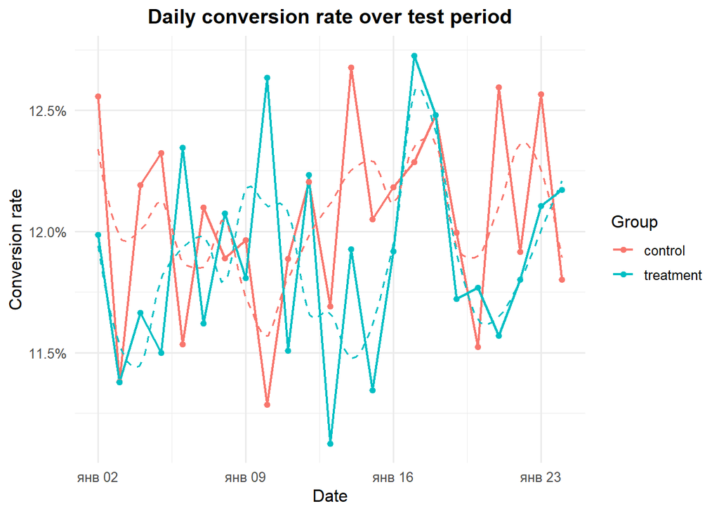

```r
daily_conv <- df %>%
  mutate(date = as.Date(timestamp)) %>%
  group_by(date, group) %>%
  summarise(
    users = n(),
    conversions = sum(converted),
    conversion_rate = conversions / users,
    .groups = "drop")

p_daily <- ggplot(daily_conv,
  aes(x = date, y = conversion_rate, colour = group)) +
  geom_line(linewidth = 0.8) +
  geom_point(size = 1.5) +
  scale_y_continuous(labels = scales::percent_format(accuracy = 0.1)) +
  geom_smooth(
      se = FALSE,        # не рисовать доверительный интервал
      method = "loess",  # локальная регрессия (гладкая кривая)
      span = 0.3,        # степень сглаживания (0.2–0.4 обычно норм)
      linewidth = 0.7,
      linetype = "dashed",
      alpha = 0.8) +
  labs(title = "Daily conversion rate over test period", x = "Date", y = "Conversion rate", colour = "Group") +
  theme_minimal(base_size = 12) +
  theme(plot.title = element_text(face = "bold", hjust = 0.5))
p_daily
```

##3. Dashboard

```r
ui <- fluidPage(
  titlePanel("A/B Test: Landing Page Conversion"),
  sidebarLayout(
    sidebarPanel(
      h4("Summary"),
      verbatimTextOutput("summary_text"),
      br(),
      h4("Test results"),
      verbatimTextOutput("test_text")
      ),
    mainPanel(
      tabsetPanel(
        tabPanel("Conversion by group",
                 plotOutput("conv_plot", height = "400px")),
        tabPanel("Daily trend",
                 plotOutput("daily_plot", height = "400px"))
      )
    )
  )
)

server <- function(input, output, session) {
  output$summary_text <- renderPrint({
    conversion_summary %>%
      mutate(conversion_rate = percent(conversion_rate, accuracy = 0.01)) %>%
      select(group, users, conversions, conversion_rate)
  })
  output$test_text <- renderPrint({
    res <- ab_test_results[1, ]
    cat(
      "Control conversion:  ", percent(res$p_control,  accuracy = 0.01), "\n",
      "Treatment conversion:", percent(res$p_treatment, accuracy = 0.01), "\n\n",
      "Difference (T - C):  ", percent(res$diff, accuracy = 0.01),
      "  (95% CI: [",
      percent(res$ci_low,  accuracy = 0.01), ", ",
      percent(res$ci_high, accuracy = 0.01), "])\n\n",
      "Z-statistic:", round(res$z_stat, 3), "\n",
      "p-value:    ", signif(res$p_value, 3), "\n"
    )
  })
  output$conv_plot <- renderPlot({
    df <- conversion_summary %>%
      mutate(
        se     = sqrt(conversion_rate * (1 - conversion_rate) / users),
        ci_low = conversion_rate - 1.96 * se,
        ci_high= conversion_rate + 1.96 * se
      )
    ggplot(df, aes(x = group, y = conversion_rate, fill = group)) +
      geom_col(width = 0.6, show.legend = FALSE) +
      scale_y_continuous(labels = percent_format(accuracy = 0.1)) +
      labs(x = "", y = "Conversion rate") +
      theme_minimal(base_size = 13)
  })

  output$daily_plot <- renderPlot({p_daily
    })
}
shinyApp(ui, server)
```

Shiny applications not supported in static R Markdown documents

Alas, the graphs don’t report any significant trend in regards to time

## Key Findings

### 1. The new version does not increase conversion

- The average conversion rate for the control and treatment groups is practically the same (the difference is within the margin of statistical error)
- The 95% confidence intervals for the conversion rates of the groups overlap significantly
- The Z-test of the difference in proportions gives a p-value > 0.05 → no statistically significant effect

**Business Impact:** - There is no reason to expect an increase in revenue/registrations when switching to the new page - The risk of metric degradation is also not confirmed

### 2. No effect over time

**Business Impact:** - There are no signs that the new page is starting to win/lose over time - The test can be considered complete, as the accumulated data is sufficient to confirm the absence of a noticeable effect